# Differential Expression Analysis of CHD2 iPSCs

Oliviero Leonardi

January 10, 2025

# 1. Data preparation

### Read data

*SE object created from exploratory analysis.*

*Gene selection according to Biotype already performed*

```r
SE_Bio <- readRDS(params$SE_Bio)
```

### Convert ENSG annotation to Gene Symbol before Differential Expression Analysis and duplicate gene names removal

*Duplicated gene names are dropped and gene IDs are set as rownames.*

**The number of duplicated GeneName is: 11899**

**The number of duplicated Ensembl Genes with version is: 0**

```r
SE_Bio <- SE_Bio[!duplicated(rowData(SE_Bio)$GeneName), ]
rownames(SE_Bio) <- rowData(SE_Bio)$GeneName
SE_Bio
## class: SummarizedExperiment
## dim: 24708 36
## metadata(0):
## assays(1): counts
## rownames(24708): TSPAN6 TNMD ... LNCDAT CDR1
## rowData names(9): Gene EnsGene ... Start End
## colnames(36): OLE_001 OLE_002 ... OLE_048 OLE_049
## colData names(11): SampleNumber SampleID_GU ... HRID lib.size
```

```r
ScaledCols <- c('darkblue', "purple","white","lightgoldenrod1", 'goldenrod1')

padj_threshold = params$padj_threshold
log2fc_threshold = params$log2fc_threshold
```

### **Filtering Thresholds are set to:**

- **Log2FC = 1.5**
- **FDR = 0.05**

### **Sample selection**

**Only iPSCs are kept**

```r
SE_Bio_iPSC <- SE_Bio[, colData(SE_Bio)$Timepoint %in% 'd0']
SE_Bio_iPSC <- SE_Bio_iPSC[, !colData(SE_Bio_iPSC)$Genotype %in% 'HT']
colData(SE_Bio_iPSC)
## DataFrame with 6 rows and 11 columns
##         SampleNumber SampleID_GU SampleID_OG             SampleName  SampleType    Genotype
##            <integer> <character> <character>            <character> <character> <character>
## OLE_001            1    IPS_X_WT    IPS_X_WT iPSCs_CHD2_WT_p63_10..       iPSCs          WT
## OLE_004            3    IPS_K_WT    IPS_K_WT iPSCs_CHD2_WT_p64_04..       iPSCs          WT
## OLE_026           13     OLE_026        OL01             1_iPSC_WTC       iPSCs          WT
## OLE_027           14     OLE_027        OL02             2_iPSC_WT3       iPSCs          WT
## OLE_028           15     OLE_028        OL03           3_iPSC_A11-5       iPSCs          AR
## OLE_029           16     OLE_029        OL04              4_iPSC_A5       iPSCs          AR
##           Timepoint       Batch    SeqRun        HRID  lib.size
##         <character> <character> <integer> <character> <numeric>
## OLE_001          d0   iPSCRound         1     OLE_001  18760237
## OLE_004          d0   iPSCRound         1     OLE_004  16535067
## OLE_026          d0        Evo1         2     OLE_026  23062896
## OLE_027          d0        Evo1         2     OLE_027  21313277
## OLE_028          d0        Evo1         2     OLE_028  23796763
## OLE_029          d0        Evo1         2     OLE_029  22872619
```

# DESeq2

## 2. Generation of the dds object

- **DDS object** is generated from the *Count Matrix* and *Sample Metadata* stored in the **SE_Bio object**
- **Genotype** is specified for the design: **Ancestral**, **Wildtype**.

```r
CountMatrix <- assays(SE_Bio_iPSC)$counts
SampleMeta <- DataFrame(colData(SE_Bio_iPSC))

all(rownames(SampleMeta) == colnames(CountMatrix))
```

```
## [1] TRUE
```

```r
dds <- DESeqDataSetFromMatrix(countData=assays(SE_Bio_iPSC)$counts, DataFrame(colData(SE_Bio_iPSC)), design = ~Batch+Genotype)
## converting counts to integer mode
## Warning in DESeqDataSet(se, design = design, ignoreRank): some variables in design formula are
## characters, converting to factors
mcols(dds) <- DataFrame(mcols(dds), DataFrame(rowData(SE_Bio_iPSC)))

dds$Genotype <- factor(dds$Genotype, levels = c("WT", "AR"))
dds$Genotype <- relevel(dds$Genotype, ref = "WT")


dds$Genotype
```

```
## [1] WT WT WT WT AR AR
## Levels: WT AR
```

```r
dds
## class: DESeqDataSet
## dim: 24708 6
## metadata(1): version
## assays(1): counts
## rownames(24708): TSPAN6 TNMD ... LNCDAT CDR1
## rowData names(9): Gene EnsGene ... Start End
## colnames(6): OLE_001 OLE_004 ... OLE_028 OLE_029
## colData names(11): SampleNumber SampleID_GU ... HRID lib.size
```

### Inspection of genes with zero counts

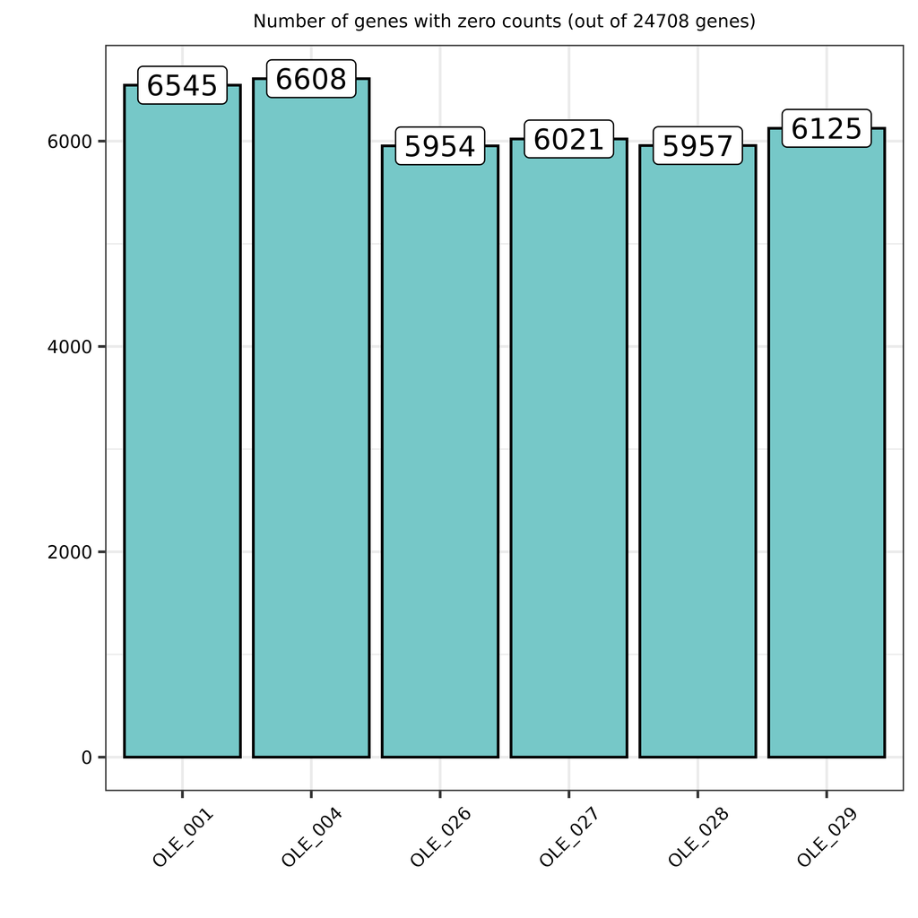

```r
ZeroPlot <- CountMatrix %>%
  mutate(row = row_number()) %>%
  pivot_longer(cols = -row, names_to = "col", values_to = "value") %>%
  filter(value == 0) %>%
  group_by(col) %>%
  summarise(zerocount = n())  %>%
  ggplot(., aes(y=col, x=zerocount)) +
  geom_col(col='black', fill='#76c8c8') +
  coord_flip() +
  geom_label(aes(label=zerocount)) +
  labs(title=paste0('Number of genes with zero counts ', '(out of ', nrow(CountMatrix), ' genes)'),
       y='', x='') +
  theme_bw() +
  theme(axis.text = element_text(colour = 'black', size=7),
        axis.text.x = element_text(angle=45, hjust = 0.5, vjust=0.5),
        plot.title = element_text(hjust = 0.5, size = 7))

ZeroPlot
```

### Filtering of the dds object

- I focus on **protein-coding** and **lncRNA** genes only (other biotypes were already removed from the SE_Bio object)
- I implement a filter on the expression of **at least 5 reads in at least 2 samples**

```r
keep <- rowSums(counts(dds)>=5) >= 2 #changed from 5 ##changed from 10 and 2 samples from 3

table(keep)
## keep
## FALSE  TRUE
##  8092 16616
dds <- dds[keep,]

dds
## class: DESeqDataSet
## dim: 16616 6
## metadata(1): version
## assays(1): counts
## rownames(16616): TSPAN6 TNMD ... ZCCHC14-DT C8orf44
## rowData names(9): Gene EnsGene ... Start End
## colnames(6): OLE_001 OLE_004 ... OLE_028 OLE_029
## colData names(11): SampleNumber SampleID_GU ... HRID lib.size
```

**A dds object containing information about 16616 genes in 6 samples is tested for differential expression.**

## 3. Differential Expression

```r
dds <- DESeq(dds)
## estimating size factors
## estimating dispersions
## gene-wise dispersion estimates
## mean-dispersion relationship
## final dispersion estimates
## fitting model and testing
sizeFactors(dds)
```

```
##   OLE_001   OLE_004   OLE_026   OLE_027   OLE_028   OLE_029
## 0.8477721 0.7508785 1.1590962 1.0702792 1.1601533 1.1212625
```

### Inspection of the dds object

#### Top50 genes heatmap

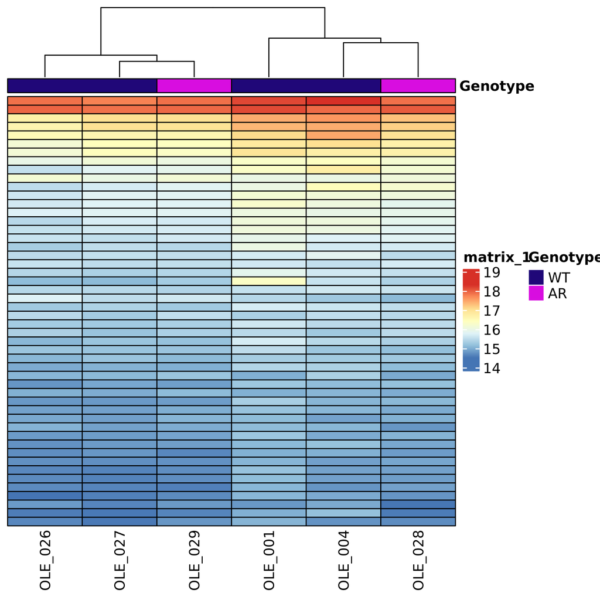

```r
select <- order(rowMeans(counts(dds,normalized=TRUE)),
                decreasing=TRUE)[1:50]
ntd <- normTransform(dds)
df <- as.data.frame(colData(dds)[,c("Genotype")])
colnames(df) <- 'Genotype'
#df$Run <- c(rep('rep1', 3), rep('rep2', 3))

rownames(df) <- colnames(ntd)

pheatmap(assay(ntd)[select,], cluster_rows=FALSE, show_rownames=FALSE,
         cluster_cols=TRUE, annotation_col=df, border_color = 'black')
```

#### Samples distances

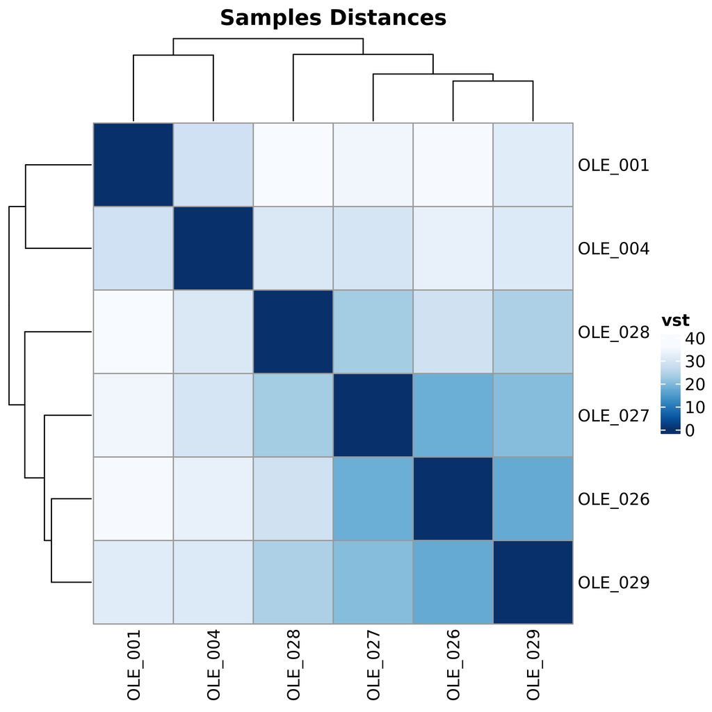

```r
vsd <- vst(dds, blind=FALSE)
sampleDists <- dist(t(assay(vsd)))

sampleDistMatrix <- as.matrix(sampleDists)
#rownames(sampleDistMatrix) <- paste(vsd$condition, vsd$type, sep="-")
#colnames(sampleDistMatrix) <- NULL
colors <- colorRampPalette(rev(RColorBrewer::brewer.pal(9, "Blues")) )(255)
pheatmap(sampleDistMatrix,
         clustering_distance_rows=sampleDists,
         clustering_distance_cols=sampleDists,
         col=colors, main = 'Samples Distances', name = 'vst')
```

#### Counts Distribution

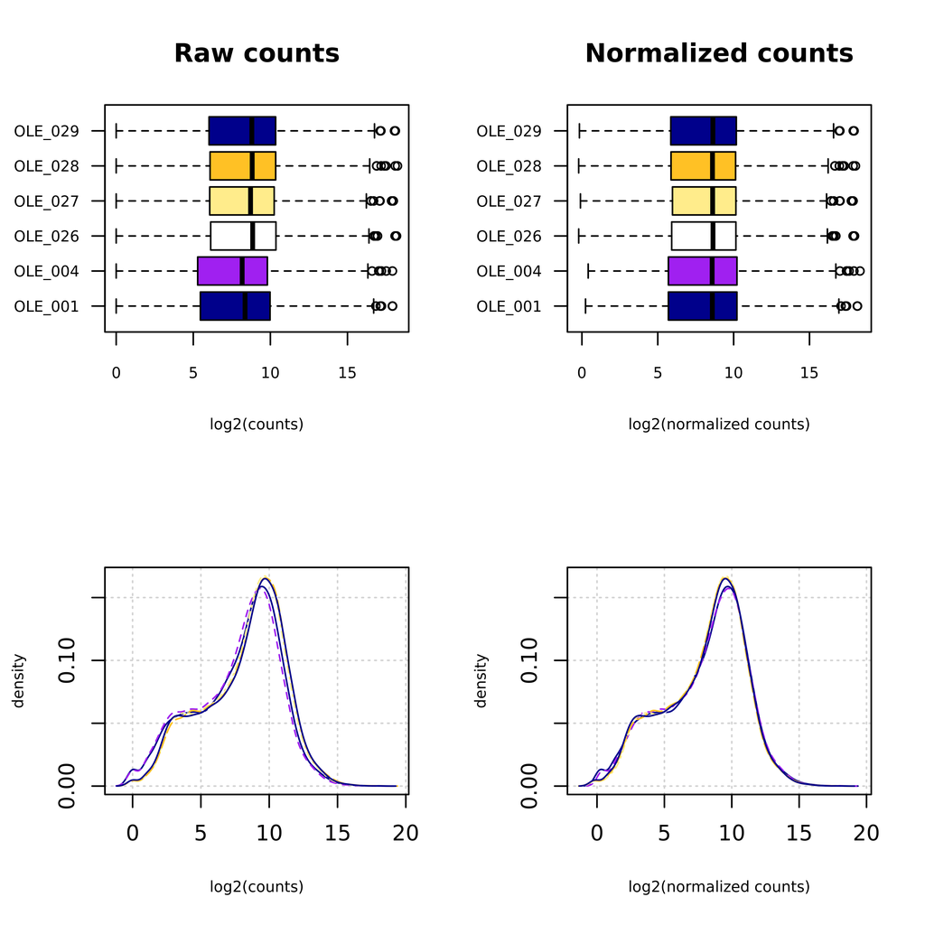

```r
SF <- data.frame(Sample=names(sizeFactors(dds)), SizeF=sizeFactors(dds))

par(mfrow=c(2,2),cex.lab=0.7)
boxplot(log2(counts(dds)),  col=ScaledCols, cex.axis=0.7,
        las=1, xlab="log2(counts)", horizontal=TRUE, main="Raw counts")
boxplot(log2(counts(dds, normalized=TRUE)),  col=ScaledCols, cex.axis=0.7,
        las=1, xlab="log2(normalized counts)", horizontal=TRUE, main="Normalized counts")
plotDensity(log2(counts(dds)),  col=ScaledCols,
            xlab="log2(counts)", cex.lab=0.7, panel.first=grid())
plotDensity(log2(counts(dds, normalized=TRUE)), col=ScaledCols,
            xlab="log2(normalized counts)", cex.lab=0.7, panel.first=grid())
```

### Dispersion estimate

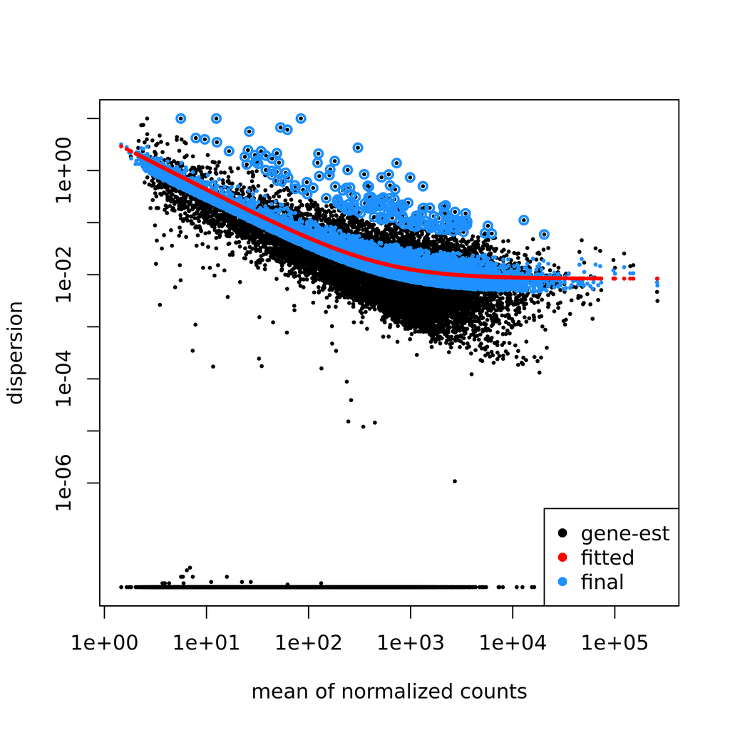

```r
plotDispEsts(dds)
```

### Extract Result of contrast: AR vs WT

```r
res_dds_ar <- results(dds, contrast=c("Genotype","AR","WT"), alpha=0.05, cooksCutoff=0.99)
summary(res_dds_ar)
```

```
##
## out of 16616 with nonzero total read count
## adjusted p-value < 0.05
## LFC > 0 (up)       : 2, 0.012%
## LFC < 0 (down)     : 23, 0.14%
## outliers [1]       : 0, 0%
## low counts [2]     : 0, 0%
## (mean count < 1)
## [1] see 'cooksCutoff' argument of ?results
## [2] see 'independentFiltering' argument of ?results
```

```r
metadata(res_dds_ar)$filterThreshold
```

```
##       0%
## 1.461506
```

```r
metadata(res_dds_ar)$alpha
```

```
## [1] 0.05
```

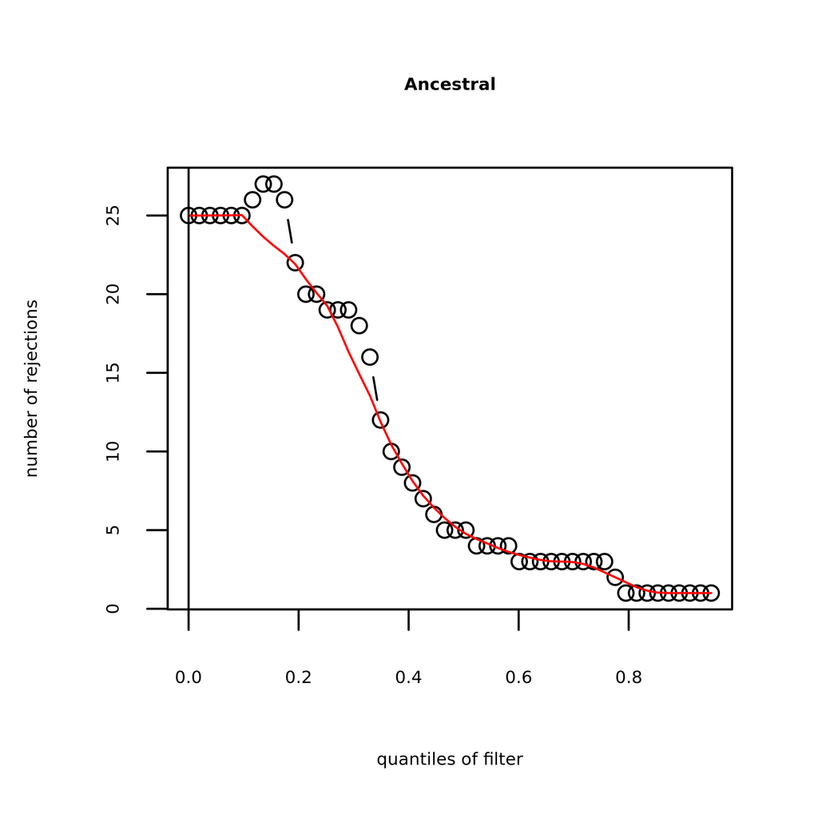

```r
plot(metadata(res_dds_ar)$filterNumRej,
     type="b", ylab="number of rejections",
     xlab="quantiles of filter", main='Ancestral',
     cex.lab=0.5, cex.axis=0.5, cex.main=0.5)
lines(metadata(res_dds_ar)$lo.fit, col="red")
abline(v=metadata(res_dds_ar)$filterTheta)
```

### Top results from res table sorted by adjusted Pvalue for AR vs WT

```r
head(res_dds_ar[order(res_dds_ar$padj),])
## log2 fold change (MLE): Genotype AR vs WT
## Wald test p-value: Genotype AR vs WT
## DataFrame with 6 rows and 6 columns
##          baseMean log2FoldChange     lfcSE      stat       pvalue         padj
##         <numeric>      <numeric> <numeric> <numeric>    <numeric>    <numeric>
## MEG3     5539.223      -11.18942  0.512289 -21.84201 9.25870e-106 1.53843e-101
## INPP5F   1225.875       -1.71328  0.150743 -11.36557  6.20601e-30  5.15595e-26
## MEG8      128.098       -4.85736  0.458638 -10.59084  3.28633e-26  1.82019e-22
## SLC15A4   115.232       -5.10798  0.529429  -9.64809  5.00775e-22  2.08022e-18
## SMIM11    120.230       -3.87240  0.425739  -9.09571  9.39708e-20  3.12284e-16
## ZNF100    325.993       -1.69163  0.217036  -7.79424  6.47995e-15  1.79452e-11
```

- Genes modulated considering a *FDR threshold of 0.1*: **29**
- Genes modulated considering a *FDR threshold of 0.05*: **25**
- Genes modulated considering a *FDR threshold of 0.05 and FC threshold of 1.5:* **25**
- Genes modulated considering a *FDR threshold of 0.05 and FC threshold of 2:* **23**

### Fold-change shrinkage

Since I am using the constrast option to retrieve the results, I cannot rely on apleglm default algorithm for logFC shrinkage. Since at the moment I am not using the lfcThreshold option, I decide for the ashr algorithm.

```r
resAshr_ar <- lfcShrink(dds, contrast=c("Genotype","AR","WT"), res=res_dds_ar, type="ashr")
## using 'ashr' for LFC shrinkage. If used in published research, please cite:
##     Stephens, M. (2016) False discovery rates: a new deal. Biostatistics, 18:2.
##     https://doi.org/10.1093/biostatistics/kxw041
summary(resAshr_ar)
```

```
##
## out of 16616 with nonzero total read count
## adjusted p-value < 0.05
## LFC > 0 (up)       : 2, 0.012%
## LFC < 0 (down)     : 23, 0.14%
## outliers [1]       : 0, 0%
## low counts [2]     : 0, 0%
## (mean count < 1)
## [1] see 'cooksCutoff' argument of ?results
## [2] see 'independentFiltering' argument of ?results
```

#### Ancestral

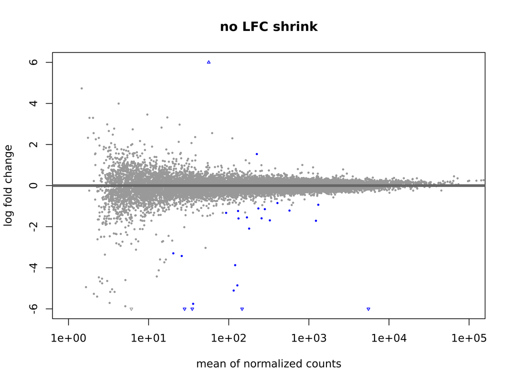

```r
#par(mfrow=c(1,2), mar=c(4,4,2,1))
xlim <- c(1,1e5); ylim <- c(-6,6)
DESeq2::plotMA(res_dds_ar, xlim=xlim, ylim=ylim, main="no LFC shrink")
```

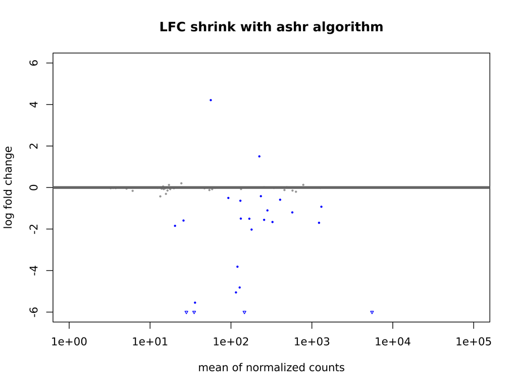

```r
DESeq2::plotMA(resAshr_ar, xlim=xlim, ylim=ylim, main="LFC shrink with ashr algorithm")
```

### Top results from res table sorted by adjpvalue after LFC shrinkage

```r
head(resAshr_ar[order(resAshr_ar$padj),])
## log2 fold change (MMSE): Genotype AR vs WT
## Wald test p-value: Genotype AR vs WT
## DataFrame with 6 rows and 5 columns
##          baseMean log2FoldChange     lfcSE       pvalue         padj
##         <numeric>      <numeric> <numeric>    <numeric>    <numeric>
## MEG3     5539.223      -11.09619  0.510150 9.25870e-106 1.53843e-101
## INPP5F   1225.875       -1.69823  0.150477  6.20601e-30  5.15595e-26
## MEG8      128.098       -4.81561  0.461028  3.28633e-26  1.82019e-22
## SLC15A4   115.232       -5.05379  0.531494  5.00775e-22  2.08022e-18
## SMIM11    120.230       -3.81378  0.434239  9.39708e-20  3.12284e-16
## ZNF100    325.993       -1.66094  0.216181  6.47995e-15  1.79452e-11
```

- Genes modulated considering a *FDR threshold of 0.1*: **29**
- Genes modulated considering a *FDR threshold of 0.05*: **25**
- Genes modulated considering a *FDR threshold of 0.05 and FC threshold of 1.5:* **23**
- Genes modulated considering a *FDR threshold of 0.05 and FC threshold of 2:* **20**

*Log Fold change shrinkage doesn’t change the results significantly, thus I decided to keep the standard DESeq2 workflow for testing differential gene expression.*

### Extract DEGs

- Here I extract the DEGs passing adjusted Pvalue and logFC thresholds, for AR vs WT contrast (deseqDEGsAR)

```r
deseqDEGsAR <- dplyr::filter(data.frame(res_dds_ar), padj < padj_threshold, abs(log2FoldChange) > log2(log2fc_threshold))

deseqDEGsARashr <- dplyr::filter(data.frame(resAshr_ar), padj < padj_threshold, abs(log2FoldChange) > log2(log2fc_threshold))
```

# Results Visualization

```r
SE_deseq2 <- as(dds, "RangedSummarizedExperiment")
assays(SE_deseq2)$vst <- assay(vst(dds, blind=TRUE))
```

```r
FdrCeil = 1e-10
logFcCeil = 7.5
```

### **Plotting Ceilings are set to:**

- **Log2FC 7.5**
- **FDR 10^{-10}**

### Volcano

#### Ancestral

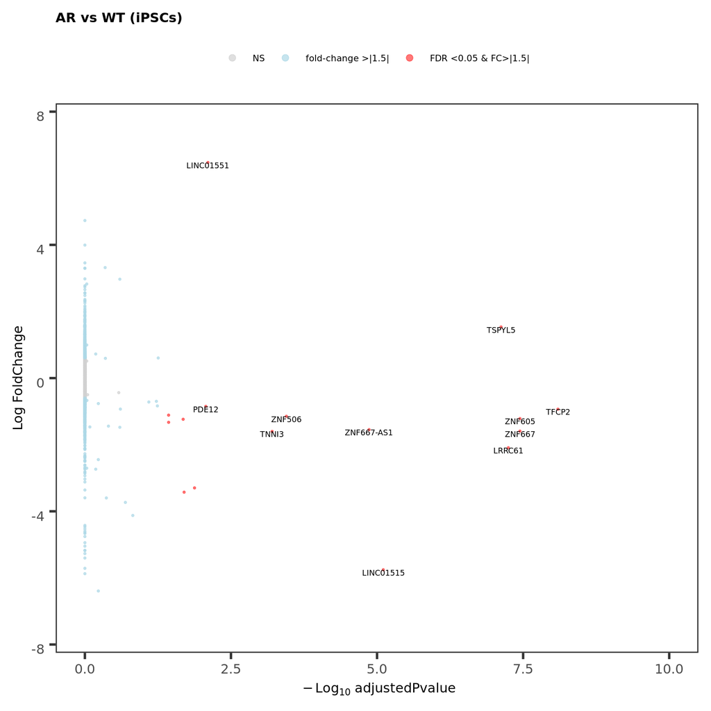

```r
#rename(as.data.frame(res_dds_ar), logFC = log2FoldChange, FDR = padj) %>% VolcanoTiltedNodash(. , AdjustedCutoff = 0.05, LabellingCutoff = 0.01, FCCutoff = 2, main = 'AR vs WT')

dplyr::rename(as.data.frame(res_dds_ar), logFC = log2FoldChange, FDR = padj) %>% VolcanoTiltedNodash(. , AdjustedCutoff = padj_threshold, LabellingCutoff = 0.01, FCCutoff = log2fc_threshold, main = 'AR vs WT (iPSCs)') + labs(y='Log FoldChange') + xlim(0, -log10(FdrCeil)) + ylim(-logFcCeil, logFcCeil)
```

#### Ancestral LFC shrink

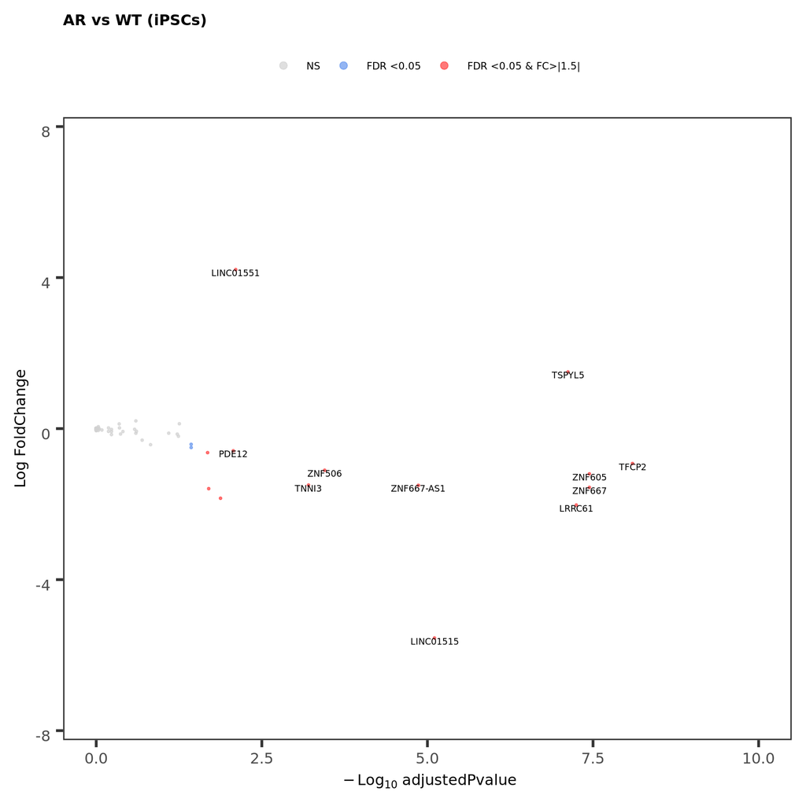

```r
#rename(as.data.frame(res_dds_ar), logFC = log2FoldChange, FDR = padj) %>% VolcanoTiltedNodash(. , AdjustedCutoff = 0.05, LabellingCutoff = 0.01, FCCutoff = 2, main = 'AR vs WT')

dplyr::rename(as.data.frame(resAshr_ar), logFC = log2FoldChange, FDR = padj) %>% VolcanoTiltedNodash(. , AdjustedCutoff = padj_threshold, LabellingCutoff = 0.01, FCCutoff = log2fc_threshold, main = 'AR vs WT (iPSCs)') + labs(y='Log FoldChange') + xlim(0, -log10(FdrCeil)) + ylim(-logFcCeil, logFcCeil)
```

### 9. Savings

```r
DEAList <- list()

DEAList <- list(dds = dds,  #same for both
                AR = list(res = res_dds_ar,
                          DEGs = deseqDEGsAR,
                          resAshr =resAshr_ar,
                          DEGsAshr = deseqDEGsARashr))
```

```r
# RDS
saveRDS(DEAList, paste0(SavingFolder, '/ipsc.', 'DEAList_AR.rds'))

saveRDS(SE_deseq2, paste0(SavingFolder, '/ipsc.', 'SE_deseq2_AR.rds'))

saveRDS(res_dds_ar, paste0(SavingFolder, '/ipsc.', 'deseqARvsWT.rds'))

SessionInfo <- sessionInfo()
Date <- date()
save.image(paste0(SavingFolder, '/ipsc.', 'DEAnalysisWorkspace_AR.RData'))
```

### **last update on: Fri Jan 10 18:47:08 2025**